# Hotel Chain Satisfaction Survey Analysis

Rahma

2025-04-16

# Hotel Guest Satisfaction Analysis

## 1. Introduction

A leading hotel chain is facing a silent crisis as they notice a huge drop in guest satisfaction rate, the mission of this analysis is to dive deep into the numbers, uncover hidden patterns, and reveal the truth behind the dissatisfaction. What stories do the guests’ ratings tell? And how can the data lead the way to transformation through data-driven insights and actionable recommendations to enhance the overall guest experience?

Due to confidentiality considerations and data protection standards, the data used in this project has been carefully simulated to reflect realistic patterns and guest behavior.

## 2. Loading Data and Packages

### Install and load necessary packages

### Load all sheets from the Excel file

```r
survey_responses <- read_excel("hotel_chain_satisfaction_survey_responses.xlsx", sheet = "survey_responses")

room_details <- read_excel("hotel_chain_satisfaction_survey_responses.xlsx", sheet = "room_details")

membership_info <- read_excel("hotel_chain_satisfaction_survey_responses.xlsx", sheet = "memberships_information")

property_info <- read_excel("hotel_chain_satisfaction_survey_responses.xlsx", sheet = "properties_info")
```

## 3. Data Cleaning

To ensure accuracy and consistency throughout this analysis the data we work with must be clean and well maintained.  
This includes checking for missing values, fixing incorrect data types, and removing duplicates if needed.

### Survey responses table

```r
# Take a look at the main data
survey_responses <- as.data.frame(survey_responses)
glimpse(survey_responses)
```

```
## Rows: 2,381
## Columns: 15
## $ reservation_number          <dbl> 759266, 21090840, 1409801, 2329308, 833445…
## $ reservation_date            <dbl> 45549, 45505, 45441, 45399, 45649, 45444, …
## $ property_code               <chr> "SPLA", "SPTX", "SPTX", "SPLA", "SPFL", "S…
## $ room_type_code              <chr> "RT729", "RT729", "RT729", "RT729", "RT254…
## $ membership_id               <chr> "MBR000676", "MBR009921", "MBR012089", "MB…
## $ visit_purpose               <chr> "Business", "Business", "Business", "Busin…
## $ csat_dsat                   <chr> "CSAT", "DSAT", "CSAT", "CSAT", "DSAT", "C…
## $ main_reason_satisfaction    <chr> "Excellent location", "NA", "Excellent loc…
## $ main_reason_dissatisfaction <chr> "NA", "Room/bedding comfort", "NA", "NA", …
## $ food_quality_rating         <dbl> 5, 3, 4, 4, 5, 4, 3, 4, 4, 2, 5, 3, 4, 3, …
## $ checkin_rating              <dbl> 2, 3, 2, 2, 4, 2, 2, 2, 2, 4, 2, 3, 2, 2, …
## $ checkout_rating             <dbl> 4, 3, 4, 5, 1, 5, 3, 5, 4, 4, 4, 3, 5, 3, …
## $ staff_friendliness          <dbl> 5, 3, 5, 5, 4, 5, 5, 4, 5, 4, 5, 3, 5, 2, …
## $ room_cleanliness            <dbl> 3, 3, 5, 4, 1, 4, 1, 5, 5, 1, 5, 4, 5, 1, …
## $ avg_ratings                 <dbl> 3.8, 3.0, 4.0, 4.0, 3.0, 4.0, 2.8, 4.0, 4.…
```

```r
# Check the structure of the data (to see data types)
str(survey_responses)
```

```
## 'data.frame':    2381 obs. of  15 variables:
##  $ reservation_number         : num  759266 21090840 1409801 2329308 83344582 ...
##  $ reservation_date           : num  45549 45505 45441 45399 45649 ...
##  $ property_code              : chr  "SPLA" "SPTX" "SPTX" "SPLA" ...
##  $ room_type_code             : chr  "RT729" "RT729" "RT729" "RT729" ...
##  $ membership_id              : chr  "MBR000676" "MBR009921" "MBR012089" "MBR015162" ...
##  $ visit_purpose              : chr  "Business" "Business" "Business" "Business" ...
##  $ csat_dsat                  : chr  "CSAT" "DSAT" "CSAT" "CSAT" ...
##  $ main_reason_satisfaction   : chr  "Excellent location" "NA" "Excellent location" "Exceptional service" ...
##  $ main_reason_dissatisfaction: chr  "NA" "Room/bedding comfort" "NA" "NA" ...
##  $ food_quality_rating        : num  5 3 4 4 5 4 3 4 4 2 ...
##  $ checkin_rating             : num  2 3 2 2 4 2 2 2 2 4 ...
##  $ checkout_rating            : num  4 3 4 5 1 5 3 5 4 4 ...
##  $ staff_friendliness         : num  5 3 5 5 4 5 5 4 5 4 ...
##  $ room_cleanliness           : num  3 3 5 4 1 4 1 5 5 1 ...
##  $ avg_ratings                : num  3.8 3 4 4 3 4 2.8 4 4 3 ...
```

```r
# Fix data structure
survey_responses <- survey_responses %>%
  mutate(reservation_date = as.Date(reservation_date, origin = "1899-12-30"))

# Check for missing values in each column
colSums(is.na(survey_responses))
```

```
##          reservation_number            reservation_date
##                           0                           0
##               property_code              room_type_code
##                           0                           0
##               membership_id               visit_purpose
##                           0                           3
##                   csat_dsat    main_reason_satisfaction
##                           0                           0
## main_reason_dissatisfaction         food_quality_rating
##                           0                           0
##              checkin_rating             checkout_rating
##                           0                           0
##          staff_friendliness            room_cleanliness
##                           0                           0
##                 avg_ratings
##                           0
```

```r
# Remove rows where visit_purpose is missing since only 3 are missing
survey_responses <- survey_responses %>%
  filter(!is.na(visit_purpose))

# Check how many duplicate rows exist
sum(duplicated(survey_responses))
```

```
## [1] 8
```

```r
# Remove the duplicate rows
survey_responses <- survey_responses[!duplicated(survey_responses), ]

# Re-check the structure, duplicates, and missing values after cleaning
str(survey_responses)
```

```
## 'data.frame':    2370 obs. of  15 variables:
##  $ reservation_number         : num  759266 21090840 1409801 2329308 983718 ...
##  $ reservation_date           : Date, format: "2024-09-14" "2024-08-01" ...
##  $ property_code              : chr  "SPLA" "SPTX" "SPTX" "SPLA" ...
##  $ room_type_code             : chr  "RT729" "RT729" "RT729" "RT729" ...
##  $ membership_id              : chr  "MBR000676" "MBR009921" "MBR012089" "MBR015162" ...
##  $ visit_purpose              : chr  "Business" "Business" "Business" "Business" ...
##  $ csat_dsat                  : chr  "CSAT" "DSAT" "CSAT" "CSAT" ...
##  $ main_reason_satisfaction   : chr  "Excellent location" "NA" "Excellent location" "Exceptional service" ...
##  $ main_reason_dissatisfaction: chr  "NA" "Room/bedding comfort" "NA" "NA" ...
##  $ food_quality_rating        : num  5 3 4 4 4 3 4 4 2 5 ...
##  $ checkin_rating             : num  2 3 2 2 2 2 2 2 4 2 ...
##  $ checkout_rating            : num  4 3 4 5 5 3 5 4 4 4 ...
##  $ staff_friendliness         : num  5 3 5 5 5 5 4 5 4 5 ...
##  $ room_cleanliness           : num  3 3 5 4 4 1 5 5 1 5 ...
##  $ avg_ratings                : num  3.8 3 4 4 4 2.8 4 4 3 4.2 ...
```

```r
colSums(is.na(survey_responses))
```

```
##          reservation_number            reservation_date
##                           0                           0
##               property_code              room_type_code
##                           0                           0
##               membership_id               visit_purpose
##                           0                           0
##                   csat_dsat    main_reason_satisfaction
##                           0                           0
## main_reason_dissatisfaction         food_quality_rating
##                           0                           0
##              checkin_rating             checkout_rating
##                           0                           0
##          staff_friendliness            room_cleanliness
##                           0                           0
##                 avg_ratings
##                           0
```

```r
sum(duplicated(survey_responses))
```

```
## [1] 0
```

```r
# Replace NA's with clear values
survey_responses <- survey_responses %>%
  mutate(
    membership_id = ifelse(is.na(membership_id), "No membership", membership_id)
  )

# Rename the satisfaction column
survey_responses <- survey_responses %>%
  rename(satisfied_or_dissatisfied = csat_dsat)

# Replace "CSAT" and "DSAT" with full, clearer words
survey_responses <- survey_responses %>%
  mutate(
    satisfied_or_dissatisfied = case_when(
      satisfied_or_dissatisfied == "CSAT" ~ "Satisfied",
      satisfied_or_dissatisfied == "DSAT" ~ "Dissatisfied",
    )
  )

# Replace NA with "Not applicable" in the two reason columns
survey_responses <- survey_responses %>%
  mutate(
    main_reason_satisfaction = ifelse(str_trim(main_reason_satisfaction) == "NA", "Not applicable", main_reason_satisfaction),
    main_reason_dissatisfaction = ifelse(str_trim(main_reason_dissatisfaction) == "NA", "Not applicable", main_reason_dissatisfaction)
  )

# Rename the satisfaction column
survey_responses <- survey_responses %>%
  rename(room_code = room_type_code)

# Final Look
head(survey_responses)
```

```
##   reservation_number reservation_date property_code room_code membership_id
## 1             759266       2024-09-14          SPLA     RT729     MBR000676
## 2           21090840       2024-08-01          SPTX     RT729     MBR009921
## 3            1409801       2024-05-29          SPTX     RT729     MBR012089
## 4            2329308       2024-04-17          SPLA     RT729     MBR015162
## 5             983718       2024-06-01          SPLA     RT254     MBR019013
## 6           30622584       2024-09-16          SPFL     RT729     MBR019633
##   visit_purpose satisfied_or_dissatisfied main_reason_satisfaction
## 1      Business                 Satisfied       Excellent location
## 2      Business              Dissatisfied           Not applicable
## 3      Business                 Satisfied       Excellent location
## 4      Business                 Satisfied      Exceptional service
## 5      Business                 Satisfied      Exceptional service
## 6      Business              Dissatisfied           Not applicable
##   main_reason_dissatisfaction food_quality_rating checkin_rating
## 1              Not applicable                   5              2
## 2        Room/bedding comfort                   3              3
## 3              Not applicable                   4              2
## 4              Not applicable                   4              2
## 5              Not applicable                   4              2
## 6            Room cleanliness                   3              2
##   checkout_rating staff_friendliness room_cleanliness avg_ratings
## 1               4                  5                3         3.8
## 2               3                  3                3         3.0
## 3               4                  5                5         4.0
## 4               5                  5                4         4.0
## 5               5                  5                4         4.0
## 6               3                  5                1         2.8
```

### Membership information table

```r
# Take a look at the main data
membership_info <- as.data.frame(membership_info)
head(membership_info)
```

```
##   membership_id membership_tier guest_age
## 1     MBR000042          Silver        35
## 2     MBR001023            Gold        26
## 3     MBR007226        Platinum        58
## 4     MBR008282          Silver        44
## 5     MBR009335            Gold        44
## 6     MBR010692            Gold        31
```

```r
glimpse(membership_info)
```

```
## Rows: 1,728
## Columns: 3
## $ membership_id   <chr> "MBR000042", "MBR001023", "MBR007226", "MBR008282", "M…
## $ membership_tier <chr> "Silver", "Gold", "Platinum", "Silver", "Gold", "Gold"…
## $ guest_age       <dbl> 35, 26, 58, 44, 44, 31, 24, 39, 28, 43, 40, 63, 32, 32…
```

```r
# Check the structure of the data (to see data types)
str(membership_info)
```

```
## 'data.frame':    1728 obs. of  3 variables:
##  $ membership_id  : chr  "MBR000042" "MBR001023" "MBR007226" "MBR008282" ...
##  $ membership_tier: chr  "Silver" "Gold" "Platinum" "Silver" ...
##  $ guest_age      : num  35 26 58 44 44 31 24 39 28 43 ...
```

```r
# Check for missing values in each column
colSums(is.na(membership_info))
```

```
##   membership_id membership_tier       guest_age
##               0               0               0
```

```r
# Check how many duplicate rows exist
sum(duplicated(membership_info))
```

```
## [1] 0
```

### Property information table

```r
# Take a look at the data
property_info <- as.data.frame(property_info)
glimpse(property_info)
```

```
## Rows: 5
## Columns: 2
## $ property_code <chr> "SPTX", "SPNJ", "SPNY", "SPLA", "SPFL"
## $ hotel_name    <chr> "Serenity Houston Hotel", "Serenity New Jersy Hotel", "S…
```

```r
# Check the structure of the data (to see data types)
str(property_info)
```

```
## 'data.frame':    5 obs. of  2 variables:
##  $ property_code: chr  "SPTX" "SPNJ" "SPNY" "SPLA" ...
##  $ hotel_name   : chr  "Serenity Houston Hotel" "Serenity New Jersy Hotel" "Serenity New York City Hotel" "Serenity Los Angelos Hotel" ...
```

```r
# Check for missing values in each column
colSums(is.na(property_info))
```

```
## property_code    hotel_name
##             0             0
```

```r
# Check how many duplicate rows exist
sum(duplicated(property_info))
```

```
## [1] 0
```

### Room details table

```r
# Take a look at the data
room_details <- as.data.frame(room_details)
glimpse(room_details)
```

```
## Rows: 5
## Columns: 12
## $ room_type         <chr> "1-Bedroom Suite", "Standard Queen", "Standard King"…
## $ room_code         <chr> "RT738", "RT729", "RT254", "RT956", "RT235"
## $ `Mattress Type`   <chr> "Memory Foam", "Hybrid Mattresses", "Hybrid Mattress…
## $ `Pillow Type`     <chr> "Memory Foam", "Down Filling", "Synthetic Hypoallerg…
## $ `Duvet Type`      <chr> "Goose Down", "Cotton Blend", "Cotton Blend", "Cotto…
## $ `Bedsheets Type`  <chr> "Egyptian Cotton", "100% Cotton", "100% Cotton", "10…
## $ `Coffee Machine`  <chr> "Yes (Nespresso)", "Yes (Keurig)", "Yes (Keurig)", "…
## $ Kettle            <chr> "Yes", "NA", "Yes", "Yes", "Yes"
## $ Hairdryer         <chr> "Yes", "NA", "Yes", "Yes", "Yes"
## $ `Room Size (sqm)` <dbl> 50, 25, 28, 30, 70
## $ `TV Size`         <chr> "55\"", "49\"", "49\"", "49\"", "65\""
## $ `Wi-Fi`           <chr> "Yes", "Yes", "Yes", "Yes", "Yes"
```

```r
# Check the structure of the data (to see data types)
str(room_details)
```

```
## 'data.frame':    5 obs. of  12 variables:
##  $ room_type      : chr  "1-Bedroom Suite" "Standard Queen" "Standard King" "Standard Twin" ...
##  $ room_code      : chr  "RT738" "RT729" "RT254" "RT956" ...
##  $ Mattress Type  : chr  "Memory Foam" "Hybrid Mattresses" "Hybrid Mattresses" "Innerspring Mattresses" ...
##  $ Pillow Type    : chr  "Memory Foam" "Down Filling" "Synthetic Hypoallergenic Filling" "Down Filling" ...
##  $ Duvet Type     : chr  "Goose Down" "Cotton Blend" "Cotton Blend" "Cotton Blend" ...
##  $ Bedsheets Type : chr  "Egyptian Cotton" "100% Cotton" "100% Cotton" "100% Cotton" ...
##  $ Coffee Machine : chr  "Yes (Nespresso)" "Yes (Keurig)" "Yes (Keurig)" "Yes (Keurig)" ...
##  $ Kettle         : chr  "Yes" "NA" "Yes" "Yes" ...
##  $ Hairdryer      : chr  "Yes" "NA" "Yes" "Yes" ...
##  $ Room Size (sqm): num  50 25 28 30 70
##  $ TV Size        : chr  "55\"" "49\"" "49\"" "49\"" ...
##  $ Wi-Fi          : chr  "Yes" "Yes" "Yes" "Yes" ...
```

```r
# Check for missing values in each column
colSums(is.na(room_details))
```

```
##       room_type       room_code   Mattress Type     Pillow Type      Duvet Type
##               0               0               0               0               0
##  Bedsheets Type  Coffee Machine          Kettle       Hairdryer Room Size (sqm)
##               0               0               0               0               0
##         TV Size           Wi-Fi
##               0               0
```

```r
# Check how if any duplicate rows exist
sum(duplicated(room_details))
```

```
## [1] 0
```

```r
# Replace NA's with proper values
room_details <- room_details %>%
  mutate(
    Kettle = ifelse(str_trim(Kettle) == "NA", "No", Kettle),
    Hairdryer = ifelse(str_trim(Hairdryer) == "NA", "No", Hairdryer)
  )

# Final Look
head(room_details)
```

```
##         room_type room_code          Mattress Type
## 1 1-Bedroom Suite     RT738            Memory Foam
## 2  Standard Queen     RT729      Hybrid Mattresses
## 3   Standard King     RT254      Hybrid Mattresses
## 4   Standard Twin     RT956 Innerspring Mattresses
## 5 2-Bedroom Suite     RT235            Memory Foam
##                        Pillow Type   Duvet Type  Bedsheets Type  Coffee Machine
## 1                      Memory Foam   Goose Down Egyptian Cotton Yes (Nespresso)
## 2                     Down Filling Cotton Blend     100% Cotton    Yes (Keurig)
## 3 Synthetic Hypoallergenic Filling Cotton Blend     100% Cotton    Yes (Keurig)
## 4                     Down Filling Cotton Blend     100% Cotton    Yes (Keurig)
## 5                          Feather   Goose Down Egyptian Cotton Yes (Nespresso)
##   Kettle Hairdryer Room Size (sqm) TV Size Wi-Fi
## 1    Yes       Yes              50     55"   Yes
## 2     No        No              25     49"   Yes
## 3    Yes       Yes              28     49"   Yes
## 4    Yes       Yes              30     49"   Yes
## 5    Yes       Yes              70     65"   Yes
```

### Final touch

Unifying names format for all tables to match the survey responses table.

```r
# Clean column names to all lowercase with underscores
room_details <- room_details %>%
  clean_names()

membership_info <- membership_info %>%
  clean_names()

property_info <- property_info %>%
  clean_names()
```

## 4. Data Preperation

In this section, we enrich the survey responses data by joining guest membership details, property information, and room features.

```r
# Enrich the survey_responses by joining the supporting tables
surveys_final <- survey_responses %>%
  left_join(membership_info, by = "membership_id") %>%
  left_join(property_info, by = "property_code") %>%
  left_join(room_details, by = "room_code")

# Rearranging the columns to a logical order
surveys_final <- surveys_final %>%
  select(
    reservation_number,
    reservation_date,
    property_code,
    hotel_name,
    room_code,
    room_type,
    mattress_type,
    pillow_type,
    duvet_type,
    bedsheets_type,
    room_size_sqm,
    membership_id,
    membership_tier,
    guest_age,
    visit_purpose,
    satisfied_or_dissatisfied,
    main_reason_satisfaction,
    main_reason_dissatisfaction,
    food_quality_rating,
    checkin_rating,
    checkout_rating,
    staff_friendliness,
    room_cleanliness,
    avg_ratings,
    everything()
  )

# Rename NA's
surveys_final<- surveys_final %>%
  mutate(
    membership_id = ifelse(membership_id == "NA", "No membership", membership_id))


surveys_final<- surveys_final %>%
  mutate(
    membership_tier = ifelse(is.na(membership_tier),"No membership", membership_tier))

surveys_final<- surveys_final %>%
  mutate(
    guest_age = ifelse(is.na(guest_age),"Not Available", guest_age))

glimpse(surveys_final)
```

```
## Rows: 2,370
## Columns: 29
## $ reservation_number          <dbl> 759266, 21090840, 1409801, 2329308, 983718…
## $ reservation_date            <date> 2024-09-14, 2024-08-01, 2024-05-29, 2024-…
## $ property_code               <chr> "SPLA", "SPTX", "SPTX", "SPLA", "SPLA", "S…
## $ hotel_name                  <chr> "Serenity Los Angelos Hotel", "Serenity Ho…
## $ room_code                   <chr> "RT729", "RT729", "RT729", "RT729", "RT254…
## $ room_type                   <chr> "Standard Queen", "Standard Queen", "Stand…
## $ mattress_type               <chr> "Hybrid Mattresses", "Hybrid Mattresses", …
## $ pillow_type                 <chr> "Down Filling", "Down Filling", "Down Fill…
## $ duvet_type                  <chr> "Cotton Blend", "Cotton Blend", "Cotton Bl…
## $ bedsheets_type              <chr> "100% Cotton", "100% Cotton", "100% Cotton…
## $ room_size_sqm               <dbl> 25, 25, 25, 25, 28, 25, 25, 70, 25, 28, 25…
## $ membership_id               <chr> "MBR000676", "MBR009921", "MBR012089", "MB…
## $ membership_tier             <chr> "Bronze", "Bronze", "Bronze", "Bronze", "B…
```

[output cut: 16 more lines]

## 5. Exploratory Data Analysis

### 5.1 Overall Satisfaction and Dissatisfaction Breakdown

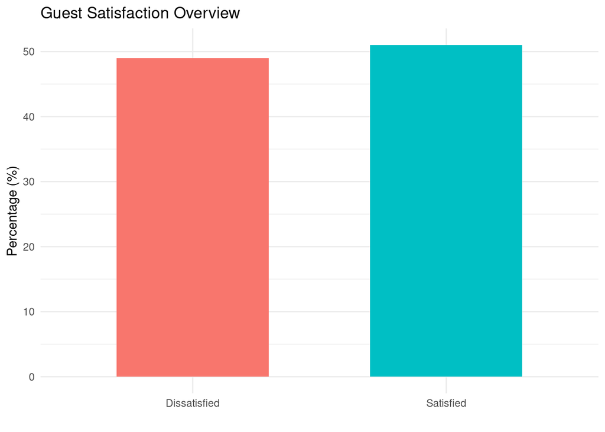

```r
# Explore Satisfaction vs. Dissatisfaction Rates
satisfaction_summary <- surveys_final %>%
  count(satisfied_or_dissatisfied) %>%
  mutate(percentage = round(100 * n / sum(n), 1))


# Plot
library(ggplot2)

ggplot(satisfaction_summary, aes(x = satisfied_or_dissatisfied, y = percentage, fill = satisfied_or_dissatisfied)) +
  geom_bar(stat = "identity", width = 0.6) +
  labs(title = "Guest Satisfaction Overview", x = "", y = "Percentage (%)") +
  theme_minimal() +
  theme(legend.position = "none")
```

```r
ggsave("satisfaction_overview_plot.png", width = 8, height = 5)
```

### 5.2 Survey Responses by Property + Satisfaction Type

We begin by exploring how guest satisfaction is distributed across the chain’s different properties. This will help reveal whether certain locations are more prone to guest dissatisfaction and allow us to prioritize improvement efforts accordingly.

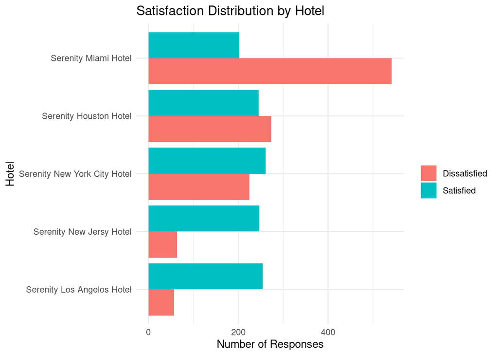

```r
surveys_final %>%
  count(hotel_name, satisfied_or_dissatisfied) %>%
  ggplot(aes(x = reorder(hotel_name, n), y = n, fill = satisfied_or_dissatisfied)) +
  geom_bar(stat = "identity", position = "dodge") +
  coord_flip() +
  labs(title = "Satisfaction Distribution by Hotel", x = "Hotel", y = "Number of Responses", fill = "") +
  theme_minimal()
```

```r
ggsave("Satisfaction Distribution by Hotel.png", width = 8, height = 5)
```

New Jersey and Los Angeles properties fall within an expected satisfaction range, meanwile the majority of dissatisfied responses are concentrated in the remaining three locations, with Florida leading by a significant margin.

### 5.3 Guest Type Distribution (Business vs Leisure) by Satisfaction

We then explore how satisfaction varies between business and leisure travelers. This lets us understand if different guest types are having different experiences, which can help tailor our recommendations.

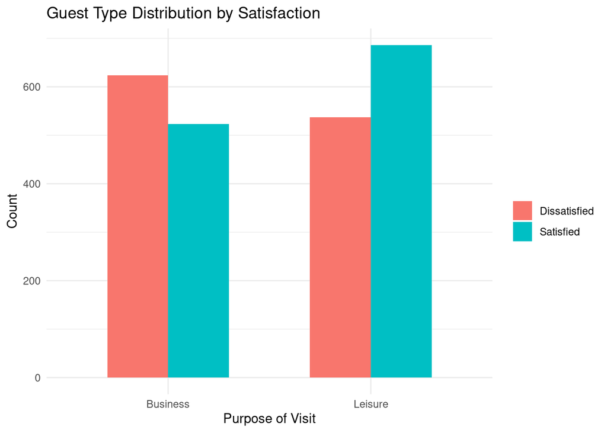

```r
surveys_final %>%
  count(visit_purpose, satisfied_or_dissatisfied) %>%
  ggplot(aes(x = visit_purpose, y = n, fill = satisfied_or_dissatisfied)) +
  geom_bar(stat = "identity", position = "dodge", width = 0.6) +
  labs(title = "Guest Type Distribution by Satisfaction", x = "Purpose of Visit", y = "Count", fill = "") +
  theme_minimal()
```

```r
ggsave("Guest Type Distribution by Satisfaction.png", width = 8, height = 5)
```

### 5.4 Membership Status Distribution by Satisfaction

Next, we look at how satisfaction breaks down across membership tiers. This helps us see if loyalty program members are having better or worse experiences compared to non-members.

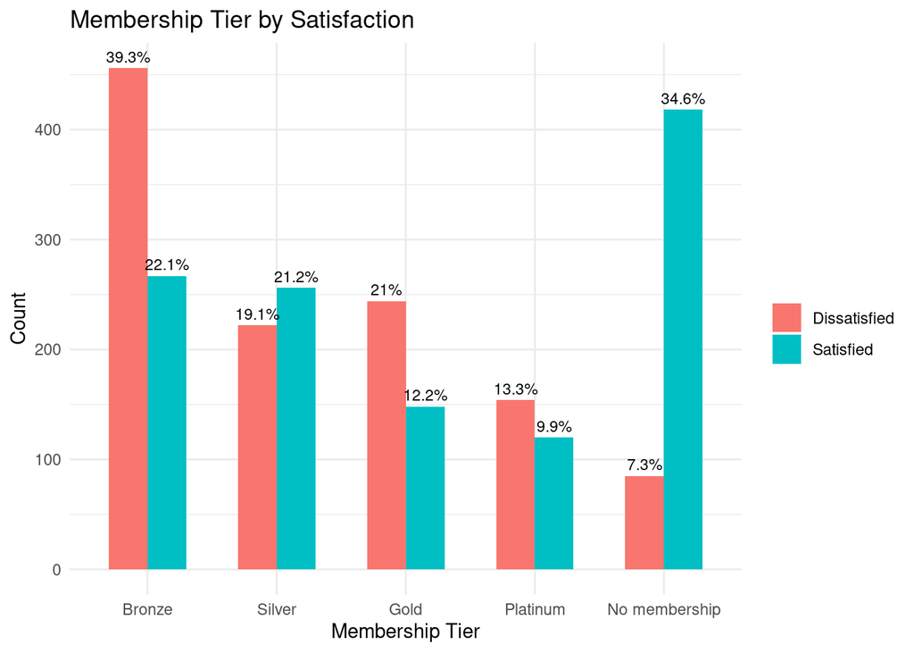

```r
surveys_final %>%
  mutate(
    membership_tier = factor(
      membership_tier,
      levels = c("Bronze", "Silver", "Gold", "Platinum", "No membership")
    )
  ) %>%
  count(membership_tier, satisfied_or_dissatisfied) %>%
  group_by(satisfied_or_dissatisfied) %>%
  mutate(percentage = round(100 * n / sum(n), 1)) %>%
  ggplot(aes(x = membership_tier, y = n, fill = satisfied_or_dissatisfied)) +
  geom_bar(stat = "identity", position = position_dodge(width = 0.6), width = 0.6) +
  geom_text(
    aes(label = paste0(percentage, "%")),
    position = position_dodge(width = 0.6),
    vjust = -0.5, size = 3
  ) +
  labs(title = "Membership Tier by Satisfaction", x = "Membership Tier", y = "Count", fill = "") +
  theme_minimal()
```

```r
ggsave("Membership Status by Satisfaction.png", width = 8, height = 5)
```

### 5.5 Satisfaction Trends Over Time

Here, we explore how satisfaction has shifted over time. This helps us understand whether things have been improving, getting worse, or staying the same.

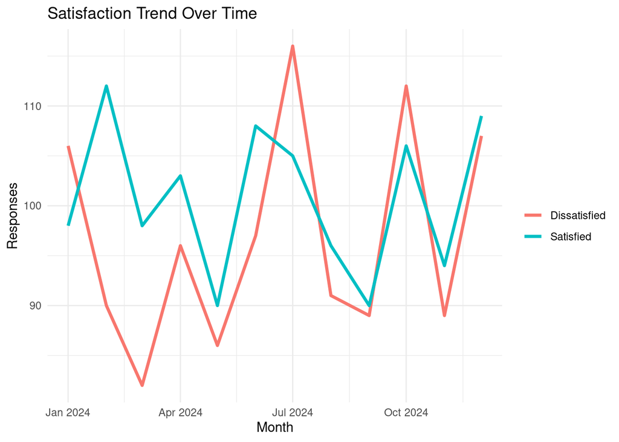

```r
library(lubridate)

surveys_final %>%
  mutate(month = floor_date(reservation_date, "month")) %>%
  count(month, satisfied_or_dissatisfied) %>%
  ggplot(aes(x = month, y = n, color = satisfied_or_dissatisfied)) +
  geom_line(size = 1.2) +
  labs(title = "Satisfaction Trend Over Time", x = "Month", y = "Responses", color = "") +
  theme_minimal()
```

### 5.6 Average Ratings by Category and Satisfaction

We then dive into the average ratings across different service areas. This gives us a more detailed view of which parts of the guest experience are working well and which need attention.

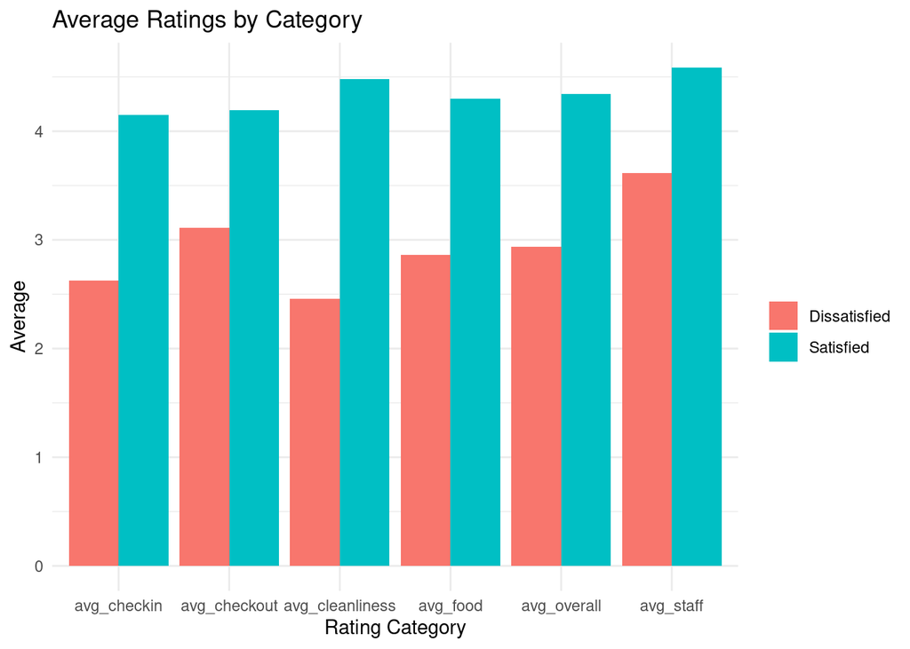

```r
surveys_final %>%
  group_by(satisfied_or_dissatisfied) %>%
  summarise(
    avg_food = mean(food_quality_rating, na.rm = TRUE),
    avg_checkin = mean(checkin_rating, na.rm = TRUE),
    avg_checkout = mean(checkout_rating, na.rm = TRUE),
    avg_staff = mean(staff_friendliness, na.rm = TRUE),
    avg_cleanliness = mean(room_cleanliness, na.rm = TRUE),
    avg_overall = mean(avg_ratings, na.rm = TRUE)
  ) %>%
  pivot_longer(cols = -satisfied_or_dissatisfied, names_to = "category", values_to = "avg_rating") %>%
  ggplot(aes(x = category, y = avg_rating, fill = satisfied_or_dissatisfied)) +
  geom_col(position = "dodge") +
  labs(title = "Average Ratings by Category", x = "Rating Category", y = "Average", fill = "") +
  theme_minimal()
```

```r
ggsave("Average Ratings by Category.png", width = 8, height = 5)
```

### 5.7 Main Reasons for Dissatisfaction

```r
# Filter only dissatisfied guests
dissatisfied_guests <- surveys_final %>%
  filter(satisfied_or_dissatisfied == "Dissatisfied")
```

```r
# Count reasons for dissatisfaction
dissatisfaction_reasons <- dissatisfied_guests %>%
  count(main_reason_dissatisfaction) %>%
  arrange(desc(n)) %>%
  mutate(percentage = round(100 * n / sum(n), 1))
```

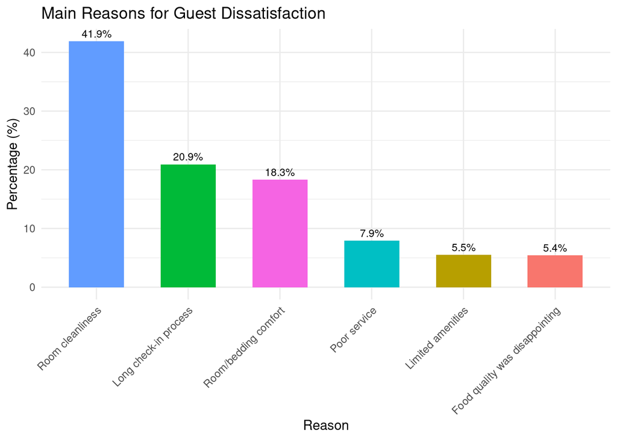

```r
# Plot the dissatisfaction reasons
ggplot(dissatisfaction_reasons, aes(x = reorder(main_reason_dissatisfaction, -percentage), y = percentage, fill = main_reason_dissatisfaction)) +
  geom_bar(stat = "identity", width = 0.6) +
  geom_text(aes(label = paste0(percentage, "%")),
            vjust = -0.5, size = 3) +
  labs(title = "Main Reasons for Guest Dissatisfaction",
       x = "Reason", y = "Percentage (%)") +
  theme_minimal() +
  theme(axis.text.x = element_text(angle = 45, hjust = 1),
        legend.position = "none")
```

```r
ggsave("Main Reasons for Guest Dissatisfaction.png", width = 8, height = 5)
```

It becomes clear that guest dissatisfaction is largely concentrated in the first three categories. To address this effectively, a deeper dive into each area is essential.

## 6. Deeper Insights

In this section, we take a closer look at the main drivers of dissatisfaction to uncover their root causes, gain a clearer understanding of the underlying issues, and provide meaningful insights that can help inform effective and targeted solutions.

### 6.1 Room cleanliness Analysis

We analyzed all dissatisfaction responses where the main reason was “Room cleanliness” to identify which properties contribute most to this issue. The pie chart below shows the percentage of cleanliness complaints contributed by each property.

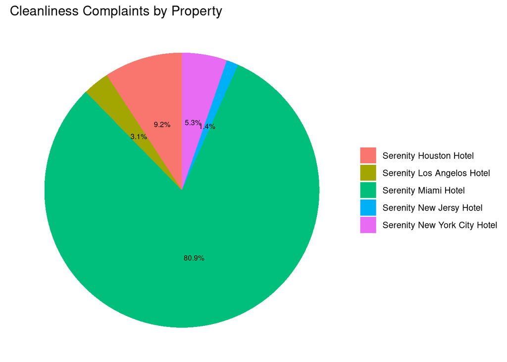

```r
surveys_final %>%
  filter(satisfied_or_dissatisfied == "Dissatisfied", main_reason_dissatisfaction == "Room cleanliness") %>%
  count(hotel_name) %>%
  mutate(percentage = round(100 * n / sum(n), 1)) %>%
  ggplot(aes(x = "", y = percentage, fill = hotel_name)) +
  geom_bar(stat = "identity", width = 1) +
  coord_polar("y") +
  geom_text(aes(label = paste0(percentage, "%")),
            position = position_stack(vjust = 0.5), size = 2.5) +
  labs(title = "Cleanliness Complaints by Property", x = "", y = "") +
  theme_void() +
  theme(legend.title = element_blank())
```

```r
ggsave("Cleanliness Complaints by Property.png", width = 8 , height = 5)
```

So we come to find out that the huge majorty of compliants that relate to cleanliness come from the same property which is the one in Miami, we want to look at all of the negative surveys that come from this specific property to understand more about the issue, and see if it would be the leading cause of disstisfaction as well.

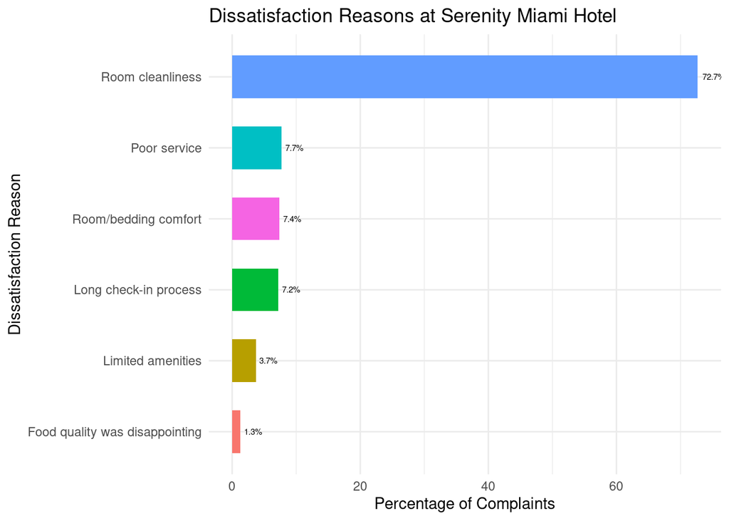

```r
surveys_final %>%
  filter(satisfied_or_dissatisfied == "Dissatisfied", hotel_name == "Serenity Miami Hotel") %>%
  count(main_reason_dissatisfaction) %>%
  mutate(percentage = round(100 * n / sum(n), 1)) %>%
  ggplot(aes(x = reorder(main_reason_dissatisfaction, n), y = percentage, fill = main_reason_dissatisfaction)) +
  geom_bar(stat = "identity", width = 0.6) +
  geom_text(aes(label = paste0(percentage, "%")),
            hjust = -0.2, size = 2) +
  coord_flip() +
  labs(title = "Dissatisfaction Reasons at Serenity Miami Hotel",
       x = "Dissatisfaction Reason",
       y = "Percentage of Complaints") +
  theme_minimal() +
  theme(legend.position = "none")
```

#### Conclusion

So we come to find that almost 81% of the cleanliness concerns come from the Miami property, and as we dig further into it, we see that nearly 73% of all dissatisfied guests from that property reported cleanliness as the main reason for their dissatisfaction. From these findings, we can conclude that the root cause of this issue, by a huge percentage, stems from the cleaning protocol and the practices of the housekeeping department in this property. Thus, from here on, it’s safe to say that addressing this issue with property management and housekeeping department management can lead to significantly improving overall satisfaction and enhancing the guest experience by around ~33% or 17 percentage points.

### 6.2 Check-in/out Dissatisfaction Analysis

As we move forward in addressing the dissatisfaction issue and working towards improving the overall guest experience, we turn to the second most common reason for dissatisfaction: the check-in and checkout process, which accounts for 20.9% of all dissatisfied responses. We dig deeper to understand where these concerns are coming from and the circumstances surrounding them, so we can better determine how to resolve this issue effectively, and so we start with seeing where they come from.

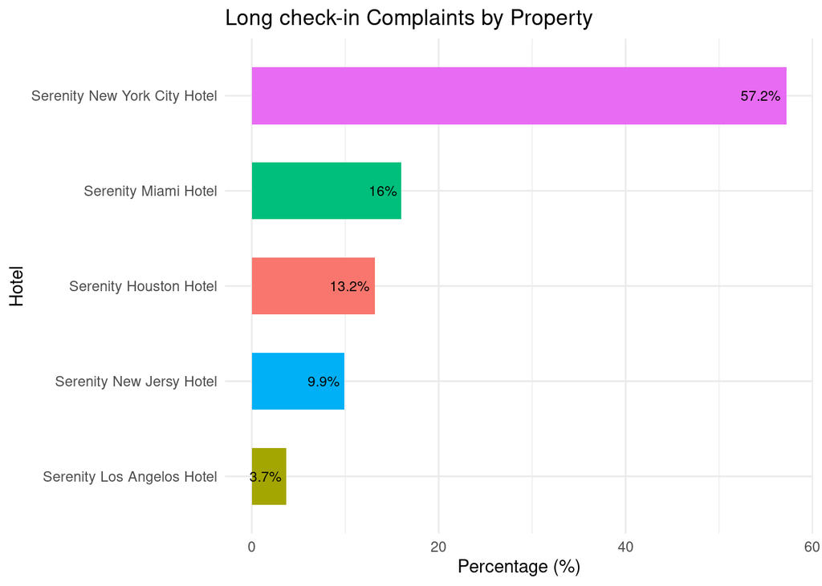

```r
#Step 1: Distribution per Property
surveys_final %>%
  filter(satisfied_or_dissatisfied == "Dissatisfied", main_reason_dissatisfaction == "Long check-in process") %>%
  count(hotel_name) %>%
  mutate(percentage = round(100 * n / sum(n), 1)) %>%
  ggplot(aes(x = reorder(hotel_name, n), y = percentage, fill = hotel_name)) +
  geom_bar(stat = "identity", width = 0.6) +
  geom_text(aes(label = paste0(percentage, "%")), hjust = 1.15, size = 3) +
  coord_flip() +
  labs(title = "Long check-in Complaints by Property", x = "Hotel", y = "Percentage (%)") +
  theme_minimal() +
  theme(legend.position = "none")
```

We see a distinctive rise in this type of complaint at the New York property, which sparks a lot of questions and interest, as New York is known for attracting both business and leisure tourism. This makes it worth examining the distribution more closely to see if any noticeable patterns emerge.

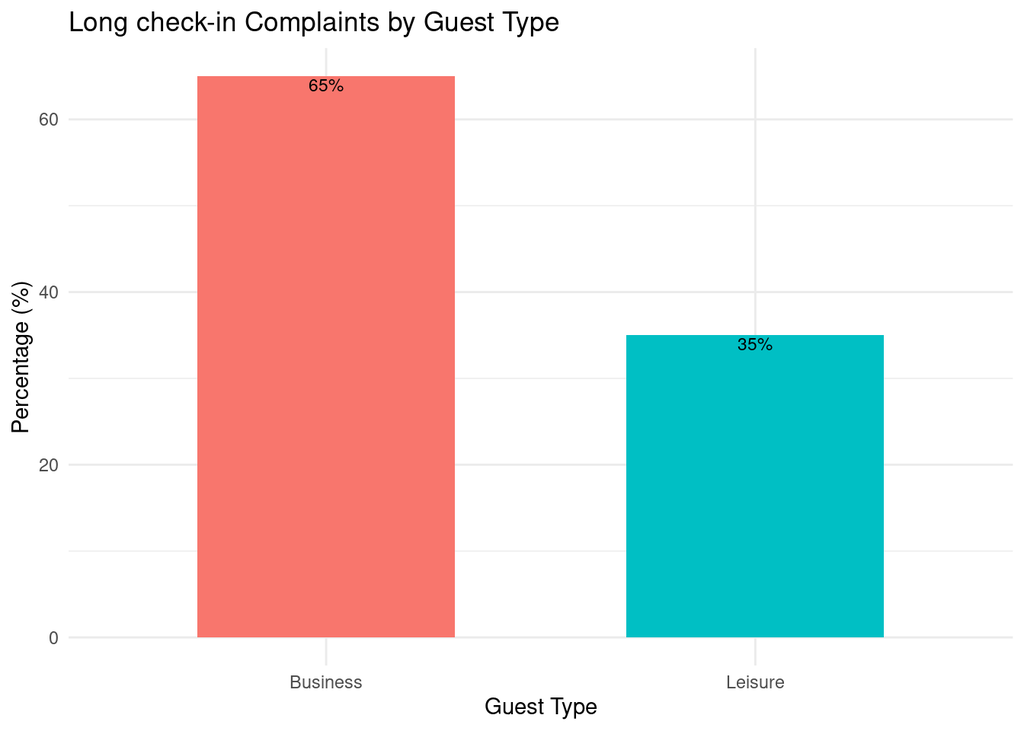

```r
#Step 3: Guest Type (Business vs Leisure)
surveys_final %>%
  filter(satisfied_or_dissatisfied == "Dissatisfied", main_reason_dissatisfaction == "Long check-in process") %>%
  count(visit_purpose) %>%
  mutate(percentage = round(100 * n / sum(n), 1)) %>%
  ggplot(aes(x = visit_purpose, y = percentage, fill = visit_purpose)) +
  geom_bar(stat = "identity", width = 0.6) +
  geom_text(aes(label = paste0(percentage, "%")), vjust = 1.15, size = 3) +
  labs(title = "Long check-in Complaints by Guest Type", x = "Guest Type", y = "Percentage (%)") +
  theme_minimal() +
  theme(legend.position = "none")
```

We see an interesting rise in long check-in complaints from business guests compared to leisure travelers, but looking at this, you can’t help but wonder — is this simply a matter of higher expectations from first-time or one-time guests? Or could it also be linked to whether guests are loyalty program members or not? Are loyalty members receiving faster or more personalized check-in compared to non-members? we need to unserstand more about these two groups.

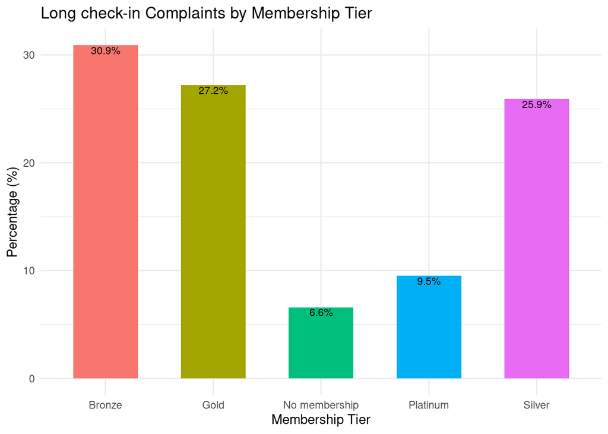

```r
#Step 3: Members vs Non-members + Membership Tiers
surveys_final %>%
  filter(satisfied_or_dissatisfied == "Dissatisfied", main_reason_dissatisfaction == "Long check-in process") %>%
  count(membership_tier) %>%
  mutate(percentage = round(100 * n / sum(n), 1)) %>%
  ggplot(aes(x = membership_tier, y = percentage, fill = membership_tier)) +
  geom_bar(stat = "identity", width = 0.6) +
  geom_text(aes(label = paste0(percentage, "%")), vjust = 1.15, size = 3) +
  labs(title = "Long check-in Complaints by Membership Tier", x = "Membership Tier", y = "Percentage (%)") +
  theme_minimal() +
  theme(legend.position = "none")
```

So now we see that the majority of guests who complain about the long check-in process are either Bronze, Gold, or Silver members, holding the top three spots by a long shot. But to establish a clearer understanding, we need to look at the relationship between membership tier and guest type.

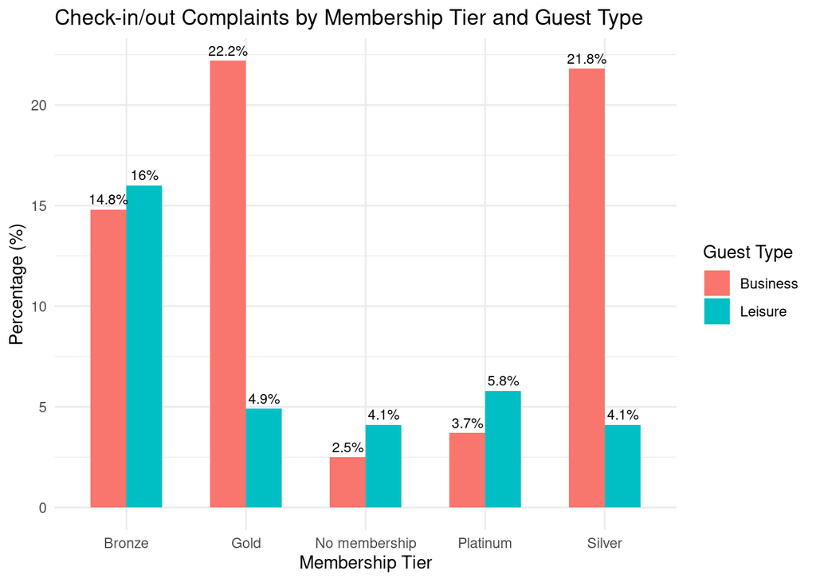

```r
surveys_final %>%
  filter(satisfied_or_dissatisfied == "Dissatisfied", main_reason_dissatisfaction == "Long check-in process") %>%
  count(membership_tier, visit_purpose) %>%
  mutate(percentage = round(100 * n / sum(n), 1)) %>%
  ggplot(aes(x = membership_tier, y = percentage, fill = visit_purpose)) +
  geom_bar(stat = "identity", position = "dodge", width = 0.6) +
  geom_text(aes(label = paste0(percentage, "%")),
            position = position_dodge(width = 0.6),
            vjust = -0.5, size = 3) +
  labs(title = "Check-in/out Complaints by Membership Tier and Guest Type",
       x = "Membership Tier", y = "Percentage (%)", fill = "Guest Type") +
  theme_minimal()
```

The large variation we see in percentages between Gold and Silver members who are business travelers and the rest of guests makes it clear that this combination dominates this category of dissatisfaction. Thus, we can safely say that the majority of dissatisfied guests citing the long check-in process as their main concern are business travelers, most of whom are loyalty program members, predominantly holding Gold, Silver, and then Bronze tiers.

#### Conclusion

Our findings suggest that the majority of guests who face this issue tend to be business travelers, who also largely fall into the Gold, Silver, and, in third place, Bronze membership tiers. We can address this issue by introducing a digital check-in feature within the loyalty platform, complete with a digital key. This would not only provide a solution for the majority affected by the problem but also serve as an incentive for the minority of non-members to enroll in the loyalty program. Therefore, arranging a meeting with the technical department to explore this solution would likely be highly effective and fruitful.

### 6.3 Room and Bedding Comfort Analysis

Moving on to the third most common reason for dissatisfaction, which accounts for 18.3% of all cases, we turn our attention to room and bedding comfort. In this section, we’ll explore the patterns behind these complaints to better understand what’s driving this issue and how it can be addressed, and since this is a room related issu, we will begin by seeing if it is relevent to one property or if the story unfolds in a different way.

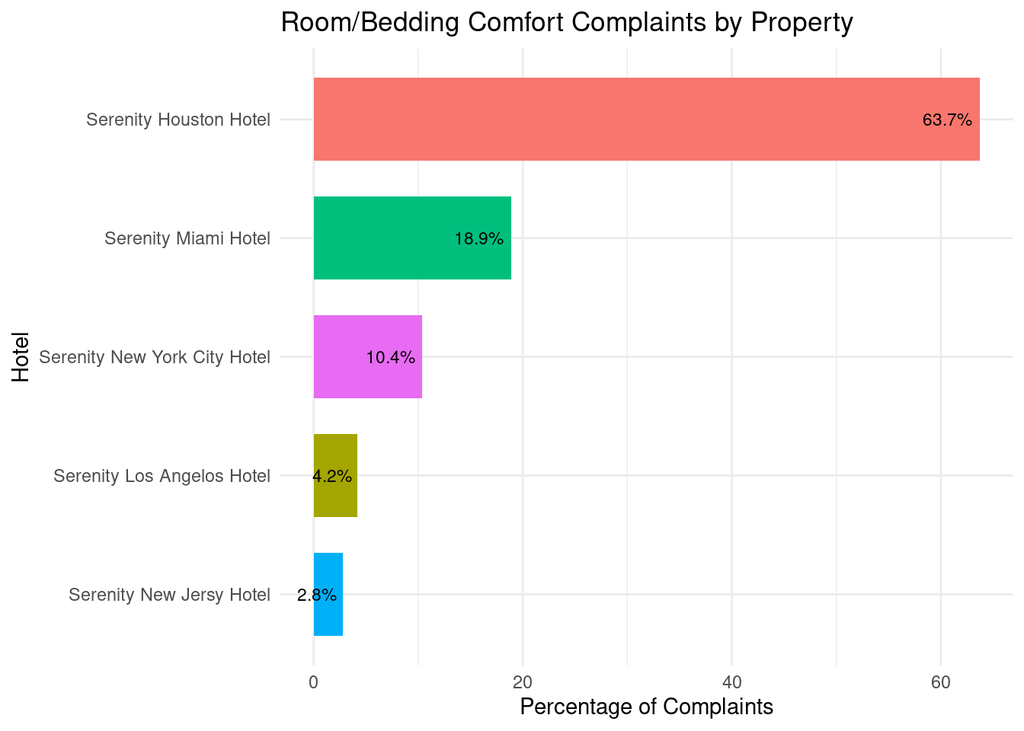

```r
#Step 1: Distribution per Property
surveys_final %>%
  filter(satisfied_or_dissatisfied == "Dissatisfied", main_reason_dissatisfaction == "Room/bedding comfort") %>%
  count(hotel_name) %>%
  mutate(percentage = round(100 * n / sum(n), 1)) %>%
  ggplot(aes(x = reorder(hotel_name, n), y = percentage, fill = hotel_name)) +
  geom_bar(stat = "identity", width = 0.7) +
  geom_text(aes(label = paste0(percentage, "%")),
            hjust = 1.15, size = 3) +
  coord_flip() +
  labs(title = "Room/Bedding Comfort Complaints by Property",
       x = "Hotel", y = "Percentage of Complaints") +
  theme_minimal() +
  theme(legend.position = "none")
```

We find that the majority of these complaints come from the Houston property, but a significant portion—about 30%, also comes from the New York and Miami properties. This raises the question of whether the issue may be more closely related to a specific room type, which we will explore next.

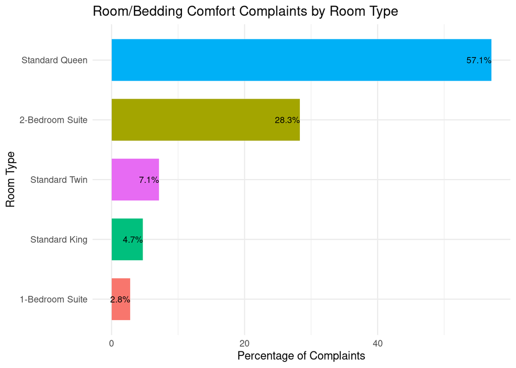

```r
#Step 2: Distribution per Room Type
surveys_final %>%
  filter(satisfied_or_dissatisfied == "Dissatisfied", main_reason_dissatisfaction == "Room/bedding comfort") %>%
  count(room_type) %>%
  mutate(percentage = round(100 * n / sum(n), 1)) %>%
  ggplot(aes(x = reorder(room_type, n), y = percentage, fill = room_type)) +
  geom_bar(stat = "identity", width = 0.7) +
  geom_text(aes(label = paste0(percentage, "%")),
            hjust = 1, size = 3) +
  coord_flip() +
  labs(title = "Room/Bedding Comfort Complaints by Room Type",
       x = "Room Type", y = "Percentage of Complaints") +
  theme_minimal() +
  theme(legend.position = "none")
```

As per the findings above, 85.4% of the comfort complaints come from just two room types: the Standard Queen and the Two-Bedroom Suites. This is an overwhelming majority, but before making any assumptions, further digging is needed. We need to explore whether there’s anything in common between these two room types, as well as examine the relationship between these rooms and the distribution of dissatisfied customers because of this specific reason across the properties to see if a similar pattern emerges.

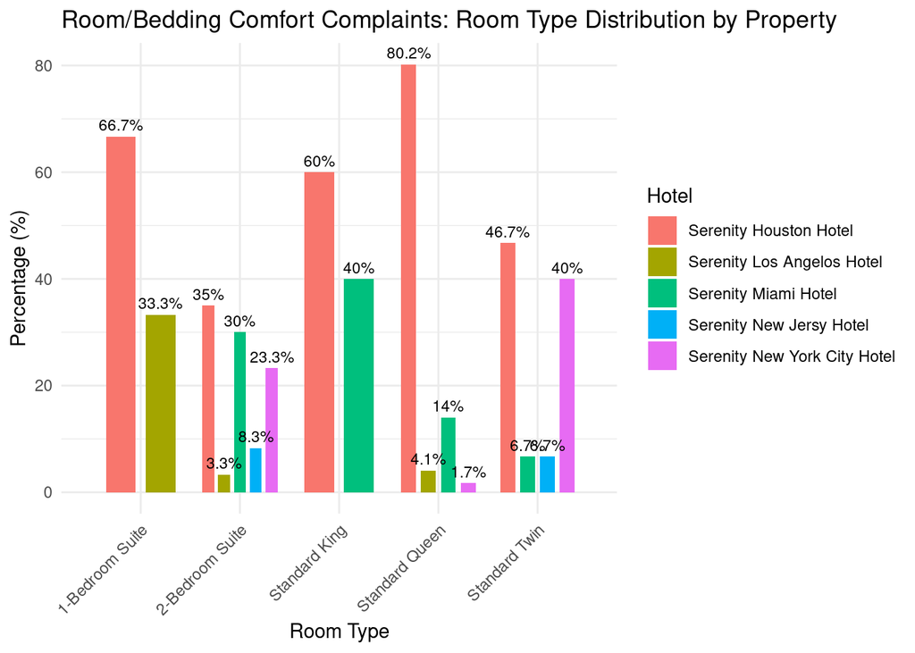

```r
surveys_final %>%
  filter(satisfied_or_dissatisfied == "Dissatisfied", main_reason_dissatisfaction == "Room/bedding comfort") %>%
  count(room_type, hotel_name) %>%
  group_by(room_type) %>%
  mutate(percentage = round(100 * n / sum(n), 1)) %>%
  ggplot(aes(x = room_type, y = percentage, fill = hotel_name)) +
  geom_bar(stat = "identity", position = position_dodge(width = 0.8), width = 0.6) +
  geom_text(aes(label = paste0(percentage, "%")),
            position = position_dodge(width = 0.8),
            vjust = -0.5, size = 3) +
  labs(title = "Room/Bedding Comfort Complaints: Room Type Distribution by Property",
       x = "Room Type", y = "Percentage (%)", fill = "Hotel") +
  scale_x_discrete(expand = c(0.2, 0)) +
  theme_minimal() +
  theme(axis.text.x = element_text(angle = 45, hjust = 1))
```

```r
DT::datatable(room_details)
```

|  | room_type | room_code | mattress_type | pillow_type | duvet_type | bedsheets_type | coffee_machine | kettle | hairdryer | room_size_sqm | tv_size | wi_fi |
| --- | --- | --- | --- | --- | --- | --- | --- | --- | --- | --- | --- | --- |
| 1 | 1-Bedroom Suite | RT738 | Memory Foam | Memory Foam | Goose Down | Egyptian Cotton | Yes (Nespresso) | Yes | Yes | 50 | 55" | Yes |
| 2 | Standard Queen | RT729 | Hybrid Mattresses | Down Filling | Cotton Blend | 100% Cotton | Yes (Keurig) | No | No | 25 | 49" | Yes |
| 3 | Standard King | RT254 | Hybrid Mattresses | Synthetic Hypoallergenic Filling | Cotton Blend | 100% Cotton | Yes (Keurig) | Yes | Yes | 28 | 49" | Yes |
| 4 | Standard Twin | RT956 | Innerspring Mattresses | Down Filling | Cotton Blend | 100% Cotton | Yes (Keurig) | Yes | Yes | 30 | 49" | Yes |
| 5 | 2-Bedroom Suite | RT235 | Memory Foam | Feather | Goose Down | Egyptian Cotton | Yes (Nespresso) | Yes | Yes | 70 | 65" | Yes |

#### Conclusion

The majority of comfort complaints come from the Houston property, with Standard Queen and Two-Bedroom Suites making up 85.4% of these issues. Looking at room details, both room types use down or feather bedding, which may contribute to discomfort. This suggests the issue is driven by both property-specific factors and bedding choices. To address these concerns, we recommend further investigation into the condition of mattresses and bedding in the affected properties, as well as considering alternative bedding options (such as hypoallergenic fills) in the most problematic room types. By targeting these areas, the hotel chain has an opportunity to significantly reduce comfort-related complaints and improve the overall guest experience.

### 6.4 Service Analysis

To understand more about this issue, we need to answer two key questions: (1) Where is the problem occurring?  
(2) Who’s experiencing it? This approach will give us better insight into what’s happening and help guide targeted solutions.

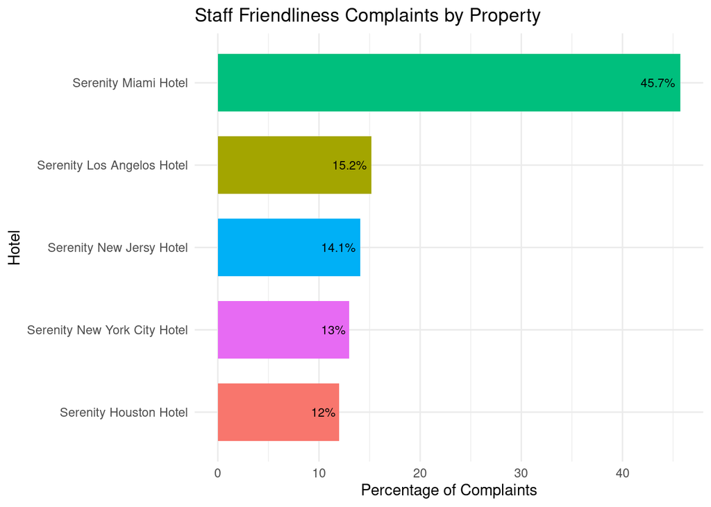

```r
surveys_final %>%
  filter(satisfied_or_dissatisfied == "Dissatisfied", main_reason_dissatisfaction == "Poor service") %>%
  count(hotel_name) %>%
  mutate(percentage = round(100 * n / sum(n), 1)) %>%
  ggplot(aes(x = reorder(hotel_name, n), y = percentage, fill = hotel_name)) +
  geom_bar(stat = "identity", width = 0.7) +
  geom_text(aes(label = paste0(percentage, "%")),
            hjust = 1.15, size = 3) +
  coord_flip() +
  labs(title = "Staff Friendliness Complaints by Property",
       x = "Hotel", y = "Percentage of Complaints") +
  theme_minimal() +
  theme(legend.position = "none")
```

While Miami is leading in frequency, it’s important to keep in mind that this property also received the largest number of surveys; the occurrence of this issue appears fairly consistent and persistent across the other properties as well.

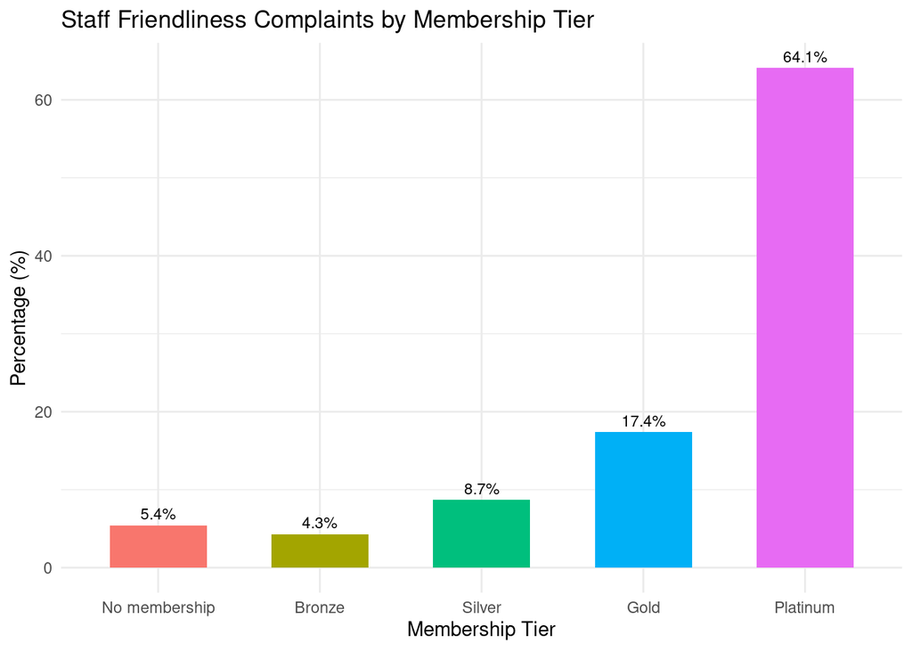

```r
surveys_final %>%
  filter(satisfied_or_dissatisfied == "Dissatisfied", main_reason_dissatisfaction == "Poor service") %>%
  count(membership_tier) %>%
  mutate(percentage = round(100 * n / sum(n), 1),
         membership_tier = factor(membership_tier, levels = c("No membership", "Bronze", "Silver", "Gold", "Platinum"))) %>%
  ggplot(aes(x = membership_tier, y = percentage, fill = membership_tier)) +
  geom_bar(stat = "identity", width = 0.6) +
  geom_text(aes(label = paste0(percentage, "%")),
            vjust = -0.5, size = 3) +
  labs(title = "Staff Friendliness Complaints by Membership Tier",
       x = "Membership Tier", y = "Percentage (%)") +
  theme_minimal() +
  theme(legend.position = "none")
```

We find here that the majority of these complaints come from Platinum members. However, before drawing any conclusions, we first need to examine the distribution of membership tiers at the Miami property to understand whether this issue is specific to that property or to Platinum members overall.

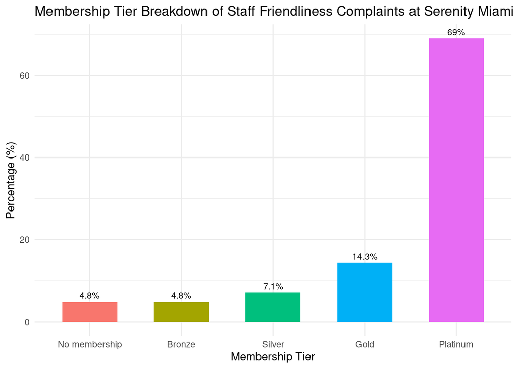

```r
surveys_final %>%
  filter(hotel_name == "Serenity Miami Hotel",
         satisfied_or_dissatisfied == "Dissatisfied",
         main_reason_dissatisfaction == "Poor service") %>%
  count(membership_tier) %>%
  mutate(percentage = round(100 * n / sum(n), 1),
         membership_tier = factor(membership_tier, levels = c("No membership", "Bronze", "Silver", "Gold", "Platinum"))) %>%
  ggplot(aes(x = membership_tier, y = percentage, fill = membership_tier)) +
  geom_bar(stat = "identity", width = 0.6) +
  geom_text(aes(label = paste0(percentage, "%")),
            vjust = -0.5, size = 3) +
  labs(title = "Membership Tier Breakdown of Staff Friendliness Complaints at Serenity Miami Hotel",
       x = "Membership Tier", y = "Percentage (%)") +
  theme_minimal() +
  theme(legend.position = "none")
```

#### Conclusion

We can now conclude that this is indeed not a property-specific issue, but rather one that Platinum members report more frequently than others. This suggests that holders of the highest membership tier likely have higher service expectations. As a result, proposing the creation of a specialized team dedicated to Platinum members could be a feasible step toward delivering more personalized and elevated service.

### 6.5 Aminities Analysis

Next, we look at how complaints about limited amenities are distributed across different room types to understand which categories are driving the most dissatisfaction.

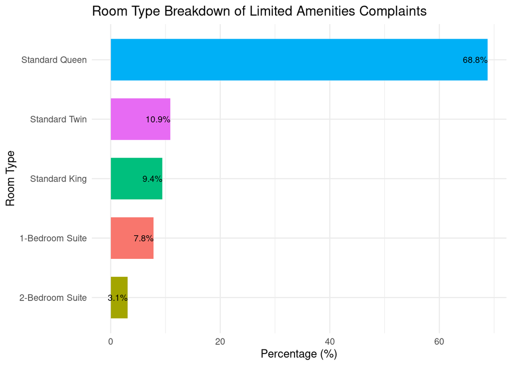

```r
surveys_final %>%
  filter(satisfied_or_dissatisfied == "Dissatisfied",
         main_reason_dissatisfaction == "Limited amenities") %>%
  count(room_type) %>%
  mutate(percentage = round(100 * n / sum(n), 1)) %>%
  ggplot(aes(x = reorder(room_type, n), y = percentage, fill = room_type)) +
  geom_bar(stat = "identity", width = 0.7) +
  geom_text(aes(label = paste0(percentage, "%")),
            hjust = 1, size = 3) +
  coord_flip() +
  labs(title = "Room Type Breakdown of Limited Amenities Complaints",
       x = "Room Type", y = "Percentage (%)") +
  theme_minimal() +
  theme(legend.position = "none")
```

We now explore how limited amenities complaints are distributed across both room types and properties to identify which combinations are driving the highest dissatisfaction.

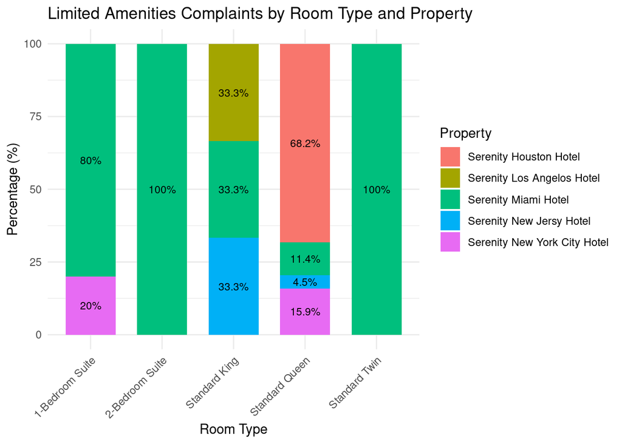

```r
surveys_final %>%
  filter(satisfied_or_dissatisfied == "Dissatisfied",
         main_reason_dissatisfaction == "Limited amenities") %>%
  count(room_type, hotel_name) %>%
  group_by(room_type) %>%
  mutate(percentage = round(100 * n / sum(n), 1)) %>%
  ggplot(aes(x = room_type, y = percentage, fill = hotel_name)) +
  geom_bar(stat = "identity", width = 0.7) +
  geom_text(aes(label = paste0(percentage, "%")),
            position = position_stack(vjust = 0.5), size = 3) +
  labs(title = "Limited Amenities Complaints by Room Type and Property",
       x = "Room Type", y = "Percentage (%)", fill = "Property") +
  theme_minimal() +
  theme(axis.text.x = element_text(angle = 45, hjust = 1))
```

We notice that the Standard Queen room is leading in complaints, so a closer look at this room’s details is necessary to better understand the issue.

```r
DT::datatable(room_details)
```

|  | room_type | room_code | mattress_type | pillow_type | duvet_type | bedsheets_type | coffee_machine | kettle | hairdryer | room_size_sqm | tv_size | wi_fi |
| --- | --- | --- | --- | --- | --- | --- | --- | --- | --- | --- | --- | --- |
| 1 | 1-Bedroom Suite | RT738 | Memory Foam | Memory Foam | Goose Down | Egyptian Cotton | Yes (Nespresso) | Yes | Yes | 50 | 55" | Yes |
| 2 | Standard Queen | RT729 | Hybrid Mattresses | Down Filling | Cotton Blend | 100% Cotton | Yes (Keurig) | No | No | 25 | 49" | Yes |
| 3 | Standard King | RT254 | Hybrid Mattresses | Synthetic Hypoallergenic Filling | Cotton Blend | 100% Cotton | Yes (Keurig) | Yes | Yes | 28 | 49" | Yes |
| 4 | Standard Twin | RT956 | Innerspring Mattresses | Down Filling | Cotton Blend | 100% Cotton | Yes (Keurig) | Yes | Yes | 30 | 49" | Yes |
| 5 | 2-Bedroom Suite | RT235 | Memory Foam | Feather | Goose Down | Egyptian Cotton | Yes (Nespresso) | Yes | Yes | 70 | 65" | Yes |

#### Conclusion

Upon review, we see that this specific room type lacks a kettle and a hairdryer, so providing these amenities could be a positive step toward addressing guest concerns.

### 6.6 Food Quality Analysis

Next, we examine how complaints about disappointing food quality are distributed across the different hotel properties to identify where this issue is most prominent.

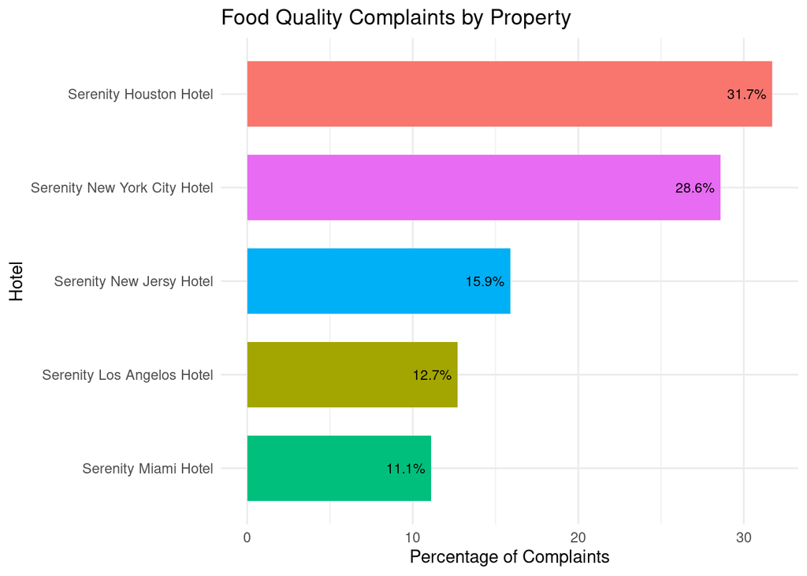

```r
surveys_final %>%
  filter(satisfied_or_dissatisfied == "Dissatisfied",
         main_reason_dissatisfaction == "Food quality was disappointing") %>%
  count(hotel_name) %>%
  mutate(percentage = round(100 * n / sum(n), 1)) %>%
  ggplot(aes(x = reorder(hotel_name, n), y = percentage, fill = hotel_name)) +
  geom_bar(stat = "identity", width = 0.7) +
  geom_text(aes(label = paste0(percentage, "%")),
            hjust = 1.15, size = 3) +
  coord_flip() +
  labs(title = "Food Quality Complaints by Property",
       x = "Hotel", y = "Percentage of Complaints") +
  theme_minimal() +
  theme(legend.position = "none")
```

#### Conclusion

We observe that the Houston and New York City properties are leading in food quality complaints, together accounting for over 60% of all cases. This suggests that focusing improvement efforts on these two locations could have the greatest impact on overall guest satisfaction regarding dining experiences.

## 7. Satisfaction Forecast

Based on the analysis, we estimated the potential improvement in overall satisfaction if all identified dissatisfaction drivers were effectively addressed. Assuming a 70% resolution success rate, the satisfaction rate is projected to increase from the current level to a significantly higher level, reflecting a meaningful uplift in guest experience.

```r
# Step 1: Count current satisfied and dissatisfied
satisfaction_summary <- surveys_final %>%
  count(satisfied_or_dissatisfied)

current_satisfied <- satisfaction_summary %>%
  filter(satisfied_or_dissatisfied == "Satisfied") %>%
  pull(n)

current_dissatisfied <- satisfaction_summary %>%
  filter(satisfied_or_dissatisfied == "Dissatisfied") %>%
  pull(n)

total_surveys <- current_satisfied + current_dissatisfied

# Step 2: Define improvement factor (adjust as you like!)
improvement_factor <- 0.7  # 70% of DSATs fixed

###a scenario assuming a 70% success rate in resolving the identified dissatisfaction drivers was modeled based on a conservative estimate commonly used in customer experience improvement initiatives.

# Step 3: Calculate potential uplift
potentially_fixed <- round(current_dissatisfied * improvement_factor)

# Step 4: Calculate forecasted satisfaction
forecasted_satisfied <- current_satisfied + potentially_fixed
forecasted_satisfaction_rate <- round(100 * forecasted_satisfied / total_surveys, 1)
current_satisfaction_rate <- round(100 * current_satisfied / total_surveys, 1)

# Step 5: Print results
cat("Current satisfaction rate:", current_satisfaction_rate, "%\n")
```

```
## Current satisfaction rate: 51 %
```

```r
cat("Forecasted satisfaction rate after improvements:", forecasted_satisfaction_rate, "%")
```

```
## Forecasted satisfaction rate after improvements: 85.3 %
```

## 9. Conclusion

### Summary of Key Findings

This analysis provided a comprehensive look into guest satisfaction across the hotel chain, identifying the main drivers of dissatisfaction and actionable solutions:

- **Room cleanliness** was the top dissatisfaction driver, heavily concentrated in one specific property. Improving housekeeping standards at this location could deliver an immediate uplift in satisfaction.
- **Check-in/check-out process** complaints were primarily from business travelers and loyalty members. Implementing digital check-in solutions could streamline their experience.
- **Room and bedding comfort** issues were linked to two room types across multiple properties, suggesting a need to standardize mattress quality.
- **Staff friendliness** complaints disproportionately came from Platinum members, indicating the opportunity to introduce a dedicated high-tier service program.
- **Amenities and food quality** accounted for smaller portions of dissatisfaction but should not be overlooked as part of a broader experience upgrade strategy.

### Satisfaction Forecast

Assuming a **70% resolution success rate** across all dissatisfaction areas, the projected satisfaction rate could improve from approximately 51% to 85.3%, representing a substantial boost in guest experience.

### Next Steps

Based on the insights uncovered in this analysis, the following targeted recommendations are proposed to improve guest satisfaction across the hotel chain:

1. **Address Cleanliness Issues**
   - Revise and reinforce housekeeping protocols at Serenity Miami Hotel.
   - Provide staff training focused on cleaning standards at Serenity Miami Hotel.
   - Conduct regular room inspections to ensure compliance for all properties.
2. **Improve Check-in/Check-out Experience, Especially for Business Guests**
   - Implement a digital check-in system and digital room key integration for loyalty members.
   - Introduce priority check-in lanes or dedicated counters for Gold, Silver, and Bronze members.
   - Provide better pre-arrival communication to set expectations.
3. **Enhance Room and Bedding Comfort in Standard Queen and Two-Bedroom Suites**
   - Audit mattresses and bedding in these room types: the Standard Queen and the Two-Bedroom Suites.
   - Offer hypoallergenic or alternative bedding options.
   - Explore guest preference options (e.g., pillow or mattress toppers) upon booking.
4. **Elevate Service for Platinum Loyalty Members**
   - Create a specialized service team or VIP concierge for Platinum members.
   - Provide staff training focused on the expectations and needs of top-tier guests.
   - Introduce personalized welcome amenities or pre-arrival.
5. **Upgrade Amenities in Standard Queen Rooms**
   - Add kettles and hairdryers to these rooms, as their absence was a key complaint.
   - Standardize essential amenities across all properties to avoid gaps.
6. **Improve Food Quality at Houston and New York Properties**
   - Focus improvement efforts on Houston and New York City properties, which account for over 60% of food complaints.
   - Conduct menu reviews and refresh culinary offerings.
   - Invest in staff training for kitchen and dining teams.
   - Gather ongoing feedback from guests to monitor improvements.

By addressing these key areas, the hotel chain can make data-driven improvements that directly impact guest loyalty and business performance.

Thank you. :)